# Irish Housing Market Analysis

Author

Ismail Khan

## The Big Idea

Big Idea is that while the Irish housing market has recovered nationally, the affordability crisis is highly unequal. Dublin hit an affordability ceiling, which forced buyers outward and violently shifted the market pressure to commuter counties.

## **Data Limitations and Uncertainty**

*It is important to note the limitations of the CSO Residential Property Price Index. Because the data is presented as an index (Base 100 = January 2005) rather than in absolute Euro values, it measures the relative rate of price growth, not actual purchasing costs. Consequently, a region with a higher index value is not necessarily more expensive in absolute terms; it has simply experienced faster proportional inflation since 2005. Furthermore, because the CSO methodology relies on stamp duty execution and mortgage drawdowns, cash-buyer transactions and off-market sales may be underrepresented, adding a slight layer of uncertainty to the exact market peak and trough measurements.*

## Exploratory Charts

### 1. The Recovery of Value

What is the long-term trajectory of the market, and how does Dublin compare to the National average?

```r
# 1. Filter to 4 series and rename for a clean legend
clean_plot_df <- plot_df %>%
  filter(`Type of Residential Property` %in% c("National - all residential properties", "Dublin - all residential properties", "National - houses", "Dublin - houses")) %>%
  mutate(`Type of Residential Property` = recode(`Type of Residential Property`,
    "National - all residential properties" = "National (All)",
    "Dublin - all residential properties"   = "Dublin (All)",
    "National - houses"                     = "National (Houses)",
    "Dublin - houses"                       = "Dublin (Houses)"))

# 2. Build the base ggplot
p1 <- ggplot(clean_plot_df, aes(x = Date, y = VALUE, colour = `Type of Residential Property`)) +
  geom_line(linewidth = 1) +
  scale_colour_manual(values = c("National (All)"="#7f8c8d", "Dublin (All)"="#2c3e50", "National (Houses)"="#3498db", "Dublin (Houses)"="#e74c3c")) +
  theme_minimal() +
  theme(panel.grid.minor = element_blank(), legend.title = element_blank()) +
  labs(title = "Irish Residential Property Price Index", subtitle = "Base: Jan 2005 = 100", x = "Year", y = "Index")

# 3. Add interactivity, fix legend, and place non-overlapping arrows
ggplotly(p1) %>%
  layout(
    legend = list(orientation = "h", x = 0, y = -0.2),
    annotations = list(
      list(x = as.numeric(as.POSIXct("2007-04-01")), y = 138, text = "Peak before the crash",
           showarrow = TRUE, ax = -60, ay = 0, font = list(size = 11, italic = TRUE)),
      list(x = as.numeric(as.POSIXct("2012-03-01")), y = 58, text = "Market bottoms out (2012)",
           showarrow = TRUE, ax = 40, ay = -40, font = list(size = 11, italic = TRUE)) # Changed ay to -40 to float above the line
    )
  )
```

[interactive chart not shown]

Figure 1

### 2. The Volatility of Growth

How violently did the market actually move year-to-year?

While the line chart shows the absolute value of homes recovering, it hides the intense volatility of the market. This bar chart looks exclusively at Dublin Houses, switching the metric from “Index Level” to “Percentage Change” — the speed of growth.

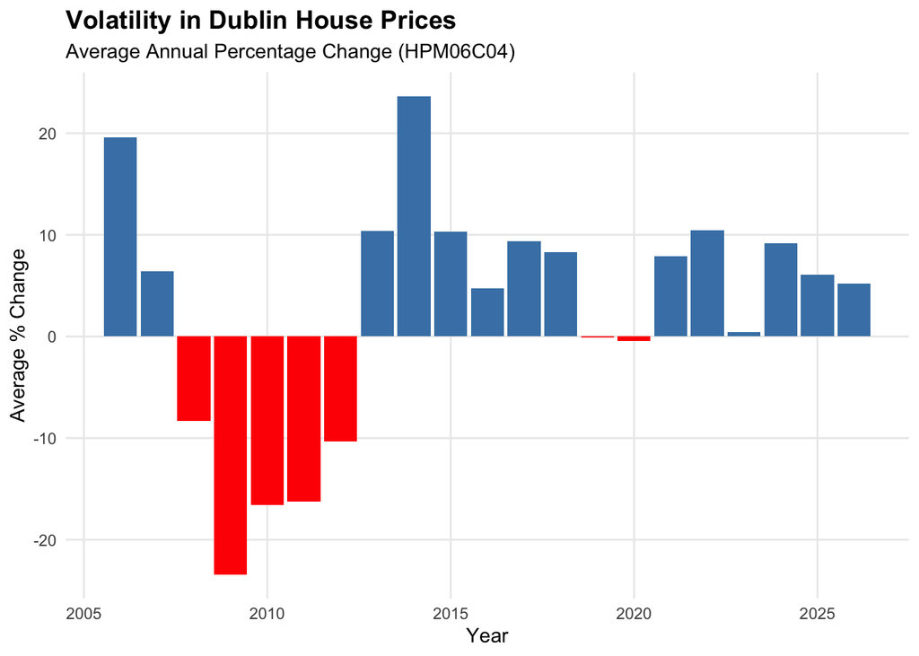

Figure 2

```r
p2 <- ggplot(pct_df, aes(x = Year, y = Avg_Change, fill = Avg_Change > 0)) +
  geom_col() +
  scale_fill_manual(values = c("TRUE" = "steelblue", "FALSE" = "red"),
                    guide = "none") +
  theme_minimal() +
  theme(panel.grid.minor = element_blank(),
        plot.title       = element_text(face = "bold", size = 14)) +
  labs(title    = "Volatility in Dublin House Prices",
       subtitle = "Average Annual Percentage Change (HPM06C04)",
       x        = "Year",
       y        = "Average % Change")

p2
```

### 3. The Shifting Pressure: Dublin vs. National Average

- When did Dublin hit its affordability ceiling and shift demand to the rest of the country?

To truly understand the uneven pressure of the market, we need to compare how Dublin performed relative to the rest of the country. This divergence area chart plots the exact difference in index points between Dublin Houses and National Houses.

When the area is blue (positive), Dublin’s index is outperforming the national average. However, the large red valley emerging from 2019 onwards reveals a critical shift — Dublin prices hit an affordability ceiling, forcing buyers outward, causing the National Index to outpace Dublin’s growth in recent years.

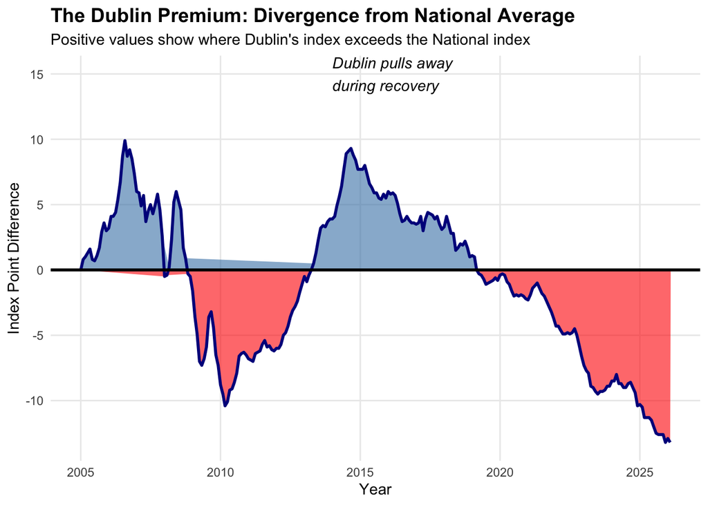

Figure 3

```r
p3_alt <- ggplot(divergence_df, aes(x = Date, y = Divergence)) +
  geom_area(aes(fill = Divergence > 0), alpha = 0.6) +
  geom_line(color = "darkblue", linewidth = 1) +
  scale_fill_manual(values = c("TRUE" = "steelblue", "FALSE" = "red"),
                    guide = "none") +
  geom_hline(yintercept = 0, color = "black", linewidth = 1) +
  theme_minimal() +
  theme(panel.grid.minor = element_blank(),
        plot.title       = element_text(face = "bold", size = 14)) +
  labs(title    = "The Dublin Premium: Divergence from National Average",
       subtitle = "Positive values show where Dublin's index exceeds the National index",
       x        = "Year",
       y        = "Index Point Difference") +
  annotate("text", x = as.POSIXct("2014-01-01"), y = 15,
           label = "Dublin pulls away\nduring recovery",
           fontface = "italic", hjust = 0)

p3_alt
```

## Explanatory Charts

How did the peak of the market differ across geographic regions?